# K means clustering in R

[k-means clustering](https://en.wikipedia.org/wiki/K-means_clustering) is a method of vector quantization, originally from signal processing, that is popular for cluster analysis in data mining. k-means clustering aims to partition n observations into k clusters in which each observation belongs to the cluster with the nearest mean, serving as a prototype of the cluster. k-means clustering is rather easy to apply to even large data sets. It has been successfully used in market segmentation, computer vision, and astronomy among many other domains. It often is used as a preprocessing step for other algorithms, for example to find a starting configuration.

```r
library(dplyr)
library(caret)
```

We will use iris dataset for this modeling. This is our dataset with categories colored using Species column.

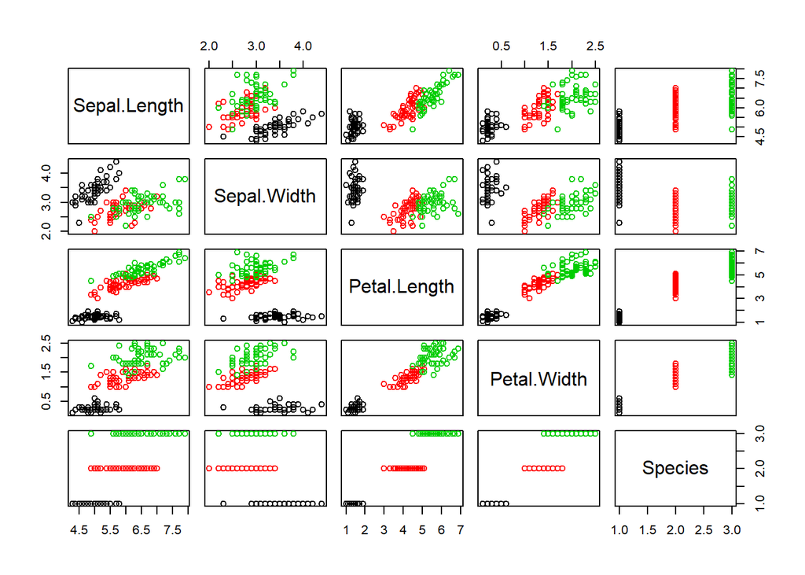

```r
plot(iris,col=iris$Species)
```

We will try to predict this categroies using k means clustering

Lets scale our data and use only continous variables

```r
irisd <- scale(iris[,-5])
head(irisd)
```

```
##      Sepal.Length Sepal.Width Petal.Length Petal.Width
## [1,]   -0.8976739  1.01560199    -1.335752   -1.311052
## [2,]   -1.1392005 -0.13153881    -1.335752   -1.311052
## [3,]   -1.3807271  0.32731751    -1.392399   -1.311052
## [4,]   -1.5014904  0.09788935    -1.279104   -1.311052
## [5,]   -1.0184372  1.24503015    -1.335752   -1.311052
## [6,]   -0.5353840  1.93331463    -1.165809   -1.048667
```

Run kmeans model with k as 3 and compare this with our original data

```r
fitk <- kmeans(irisd,3)
```

lets look what’s available in fitk

```r
str(fitk)
```

```
## List of 9
##  $ cluster     : int [1:150] 3 3 3 3 3 3 3 3 3 3 ...
##  $ centers     : num [1:3, 1:4] 1.1322 -0.0501 -1.0112 0.0881 -0.8804 ...
##   ..- attr(*, "dimnames")=List of 2
##   .. ..$ : chr [1:3] "1" "2" "3"
##   .. ..$ : chr [1:4] "Sepal.Length" "Sepal.Width" "Petal.Length" "Petal.Width"
##  $ totss       : num 596
##  $ withinss    : num [1:3] 47.5 44.1 47.4
##  $ tot.withinss: num 139
##  $ betweenss   : num 457
##  $ size        : int [1:3] 47 53 50
##  $ iter        : int 2
##  $ ifault      : int 0
##  - attr(*, "class")= chr "kmeans"
```

lets map cluster from fitk against the Species variable from Iris dataset

```r
table(fitk$cluster,iris$Species)
```

```
##
##     setosa versicolor virginica
##   1      0         11        36
##   2      0         39        14
##   3     50          0         0
```

You can see that this did not yield good prediction

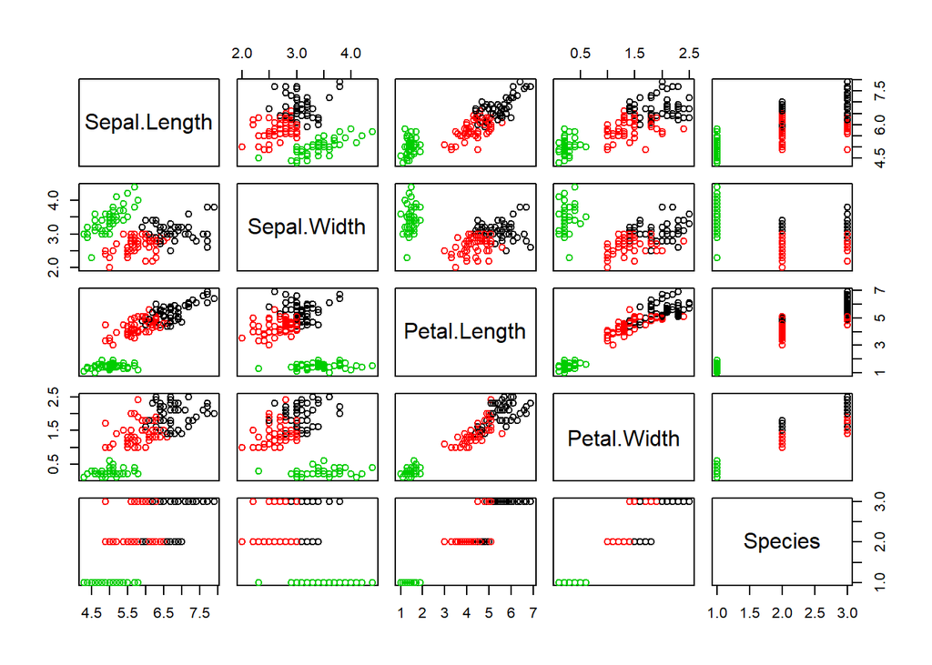

```r
plot(iris,col=fitk$cluster)
```

now lets try to identify optimal k

```r
k<-list()
for(i in 1:10) {
  k[[i]]<-kmeans(irisd,i)
}
```

Lets plot sum of squares for different k values

```r
finalss <- list()
for(i in 1:10) {
  finalss[[i]] <- k[[i]]$betweenss/k[[i]]$totss
}
finalss
```

```
## [[1]]
## [1] 1.907497e-16
##
## [[2]]
## [1] 0.6293972
##
## [[3]]
## [1] 0.7669658
##
## [[4]]
## [1] 0.8087749
##
## [[5]]
## [1] 0.8243863
##
## [[6]]
## [1] 0.8410118
##
## [[7]]
## [1] 0.8787135
##
## [[8]]
## [1] 0.8819321
##
## [[9]]
## [1] 0.9037063
##
## [[10]]
## [1] 0.9016355
```

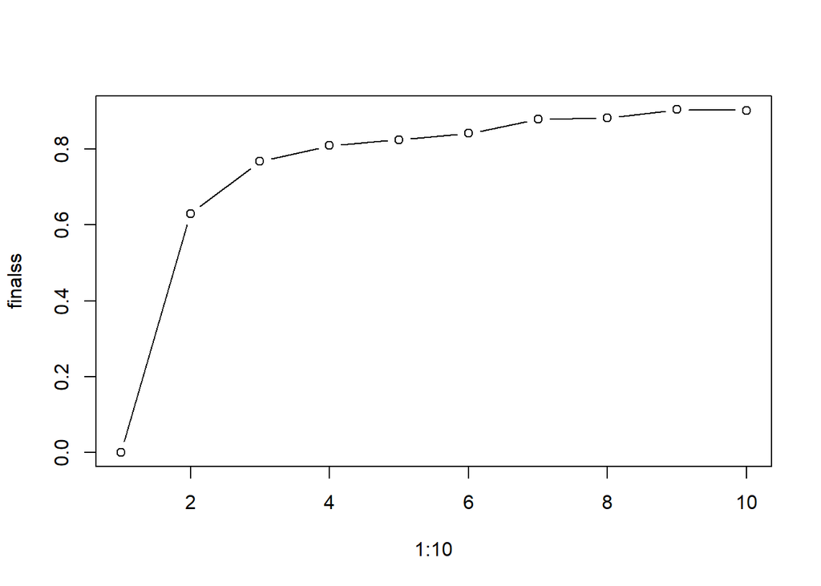

```r
plot(1:10,finalss,type = 'b')
```

As you can see in plot after K value 2 or 3 the shoulder flattens, so there isn’t much variation that is idnetifed by higher values of k

```r
table(k[[2]]$cluster,iris$Species)
```

```
##
##     setosa versicolor virginica
##   1     50          0         0
##   2      0         50        50
```

```r
table(k[[3]]$cluster,iris$Species)
```

```
##
##     setosa versicolor virginica
##   1      0         11        36
##   2      0         39        14
##   3     50          0         0
```

```r
table(k[[4]]$cluster,iris$Species)
```

```
##
##     setosa versicolor virginica
##   1      0         11        36
##   2     16          0         0
##   3      0         39        14
##   4     34          0         0
```

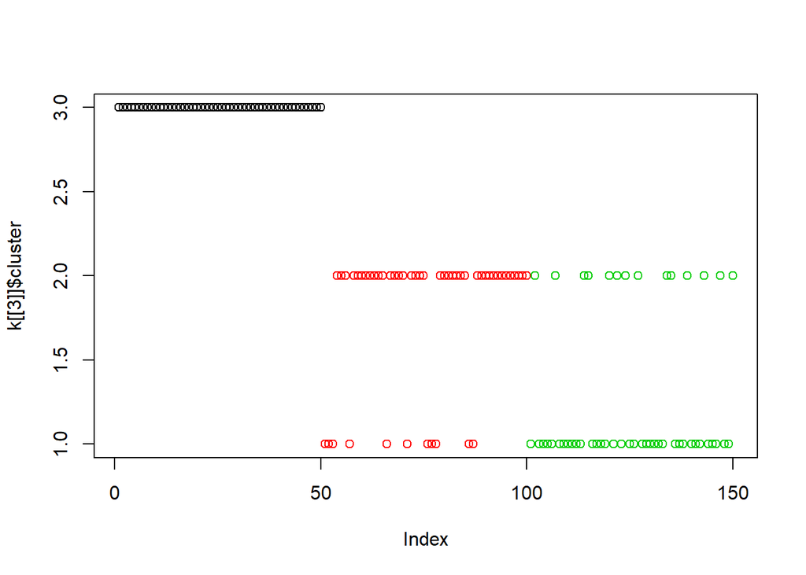

```r
plot(k[[3]]$cluster,col=iris$Species)
```